# Divvy Bike Analysis

## Introduction

Public bike share (PBS).

A PBS is an extension of the existing transit system with a network of short-term, self-service bicycle posts in which:

- Users can use bikes by purchasing casual day use or annual memberships,
- Users can ride bikes for a short distance for one-way trips within a defined service area and Station locations can change overtime based on ridership practices or operation needs.

Bike share technology continues to evolve quickly along with other wireless and digital changes. Other recent advancements include systems that do not require docking stations i.e. “smart lock” systems and electric‐assist bikes.

### About this dataset

I used 1 year (12 Months) of Divvy Chicago Bike Sharing Data from Jan 2024 to Dec 2024, obtained from Divvy Bike .

#### Missing features

Although this dataset is not a result of a survey, The following missing features could make this analysis more interesting and stronger if were exist.

- Bike ID,
- User ID,
- User Gender,
- User Age,
- Purpose of trip,
- Trip distance and
- Weather conditions.

I believe some of them are connected to the agreed privacy policy!

Anyway, let’s load the packages we need for this brief analysis

```r
library(tidyverse)
library(paletteer)
library(PNWColors)
library(leaflet)
scale_colour_paletteer_d("PNWColors::Sunset")
scale_fill_paletteer_d("PNWColors::Sunset")
theme_set(theme_minimal())
```

Here, `tidyverse` is for analysis, `paletteer` is for creating custom color pallete, and `leaflet` is for creating maps.

## Reading the datasets

Here, we used `read.csv` function to read all 12 months into the dataset in R.

```r
january <- read.csv("datasets/202401-divvy-tripdata.csv")
february <- read.csv("datasets/202402-divvy-tripdata.csv")
march <- read.csv("datasets/202403-divvy-tripdata.csv")
april <- read.csv("datasets/202404-divvy-tripdata.csv")
may <- read.csv("datasets/202405-divvy-tripdata.csv")
june <- read.csv("datasets/202406-divvy-tripdata.csv")
july <- read.csv("datasets/202407-divvy-tripdata.csv")
august <- read.csv("datasets/202408-divvy-tripdata.csv")
september <- read.csv("datasets/202409-divvy-tripdata.csv")
october <- read.csv("datasets/202410-divvy-tripdata.csv")
november <- read.csv("datasets/202411-divvy-tripdata.csv")
december <- read.csv("datasets/202412-divvy-tripdata.csv")
```

## Combining the datasets

Here, we combine all monthly datasets into a single dataset for easier analysis. Additionally, a `month` column is added to each dataset to identify the month of each ride.

```r
df <- bind_rows(
    january |> mutate(month = 1),
    february |>  mutate(month = 2),
    march|>  mutate(month = 3),
    april|>  mutate(month = 4),
    may|>  mutate(month = 5),
    june|>  mutate(month = 6),
    july |> mutate(month = 7),
    august |> mutate(month = 8),
    september |> mutate(month = 9),
    october |> mutate(month = 10),
    november |> mutate(month = 11),
    december|>  mutate(month = 12)
)
```

## Creating New Columns

To enhance our analysis, we derive new columns such as `time_of_day` using the `hour` function from the `lubridate` package, and `season` using the `month` function.

```r
df <- df |>
    mutate(hour = hour(started_at)) |>
    mutate(time_of_day =
    case_when (
      hour %in% 0:5 ~ "Night",
      hour %in% 6:11 ~ "Morning",
      hour %in% 12:17 ~ "Afternoon",
      hour %in% 18:23 ~ "Evening"
        )
    )
```

Simlarly, we derive the `season` column using the `month` from the dataframe.

```r
df <- df  |>
    mutate(season =
    case_when (
        month %in% c(12, 1, 2) ~ "Winter",
        month %in% c(3, 4, 5) ~ "Spring",
        month %in% c(6, 7, 8) ~ "Summer",
        month %in% c(9, 10, 11) ~ "Fall"
    )
)
```

# Exploratory Data Analysis

In this section, we will analyze the data and visualize the results using various plots. We will focus on the following aspects:

- Ride type by user
- Ride type by bikes
- Average ride length
- Ride length by weekday
- Total rides by weekday
- Total rides by hour
- Total rides by month
- Average ride length by season
- Top 10 starting and ending stations
- Ride type by user

This section analyzes ride types based on user type (`member` vs. `casual`). The data is grouped and visualized in a pie chart to show the proportion of rides for each user type.

## Ride Type by Rider

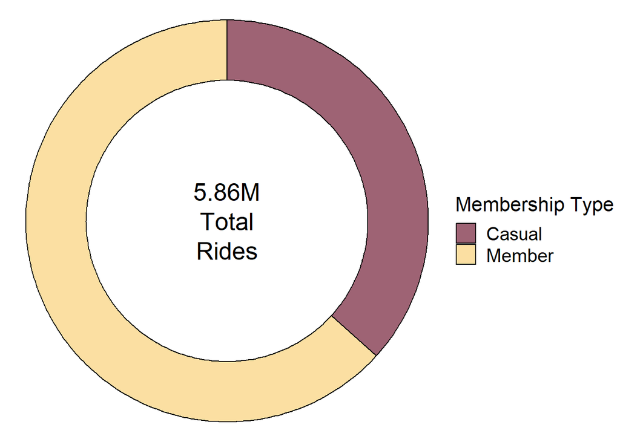

```r
ride_type_by_user <- df |>
    group_by(member_casual) |>
    summarise(count = n()) |>
    mutate(
        proportion = count / sum(count),
        percentage = count / sum(count) * 100,
    )

ride_type_by_user |>
    mutate(
        start = lag(proportion, default = 0) * 2 * pi,
        end = cumsum(proportion) * 2 * pi,
    ) |>
    ggplot() +
    ggforce::geom_arc_bar(
        aes(
            x0 = 0, y0 = 0,
            r0 = 0.7, r = 1,
            start = start,
            end = end,
            fill = member_casual  # Ensure 'fill' is mapped to a variable
        )
    ) +
    annotate(
      'text',
      x = 0,
      y = 0,
      label = paste0(round(nrow(df) / 1000000, 2), "M\nTotal\nRides"),
      size = 7,
      lineheight = 1
    ) +
    coord_equal(expand = FALSE, xlim = c(-1.1, 1.1), ylim = c(-1.1, 1.1)) +
    theme_void(base_size = 16) +
    labs(
        fill = "Membership Type"  # Add a meaningful label for the legend
    ) +
    theme(
        legend.position = "right",  # Place the legend on the right
        legend.margin = margin(t = 1, b = 0.5, unit = 'cm'),
        legend.text = element_text(size = 15)
    ) +
    scale_fill_manual(
        values = pnw_palette("Sunset", n = 2),
        labels = c("Casual", "Member")  # Custom labels for legend categories
    )
```

## Ride Type By Rideable

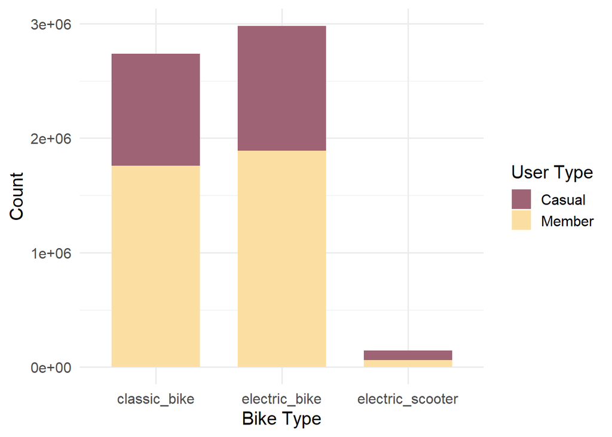

```r
ride_type_by_rideable <- df |>
    group_by(rideable_type, member_casual) |>
    summarise(count = n(), .groups = 'drop')

ggplot(ride_type_by_rideable, aes(x = rideable_type, y = count, fill = member_casual)) +
    geom_bar(stat = "identity", position = "stack", width = 0.7) +
    labs(
        x = "Bike Type",
        y = "Count",
        fill = "User Type"
    ) +
    theme_minimal(base_size = 15) +
    scale_fill_manual(values = pnw_palette("Sunset", n = 2), labels = c("Casual", "Member"))
```

## Average Ride Length

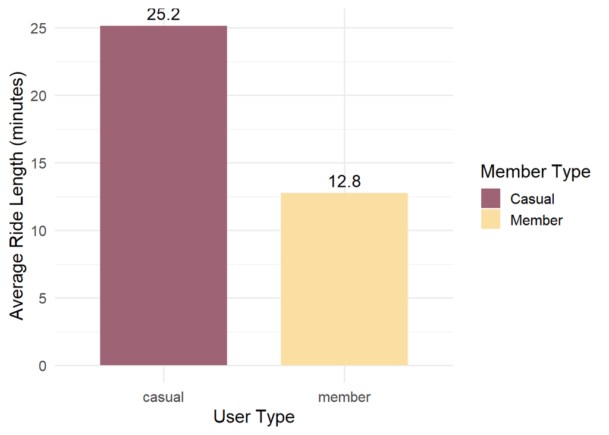

```r
## Average Ride Length
average_ride_length <- df |>
    mutate(ride_length = as.numeric(difftime(ended_at, started_at, units = "mins"))) |>
    group_by(member_casual) |>
    summarise(average_ride_length = mean(ride_length, na.rm = TRUE))

ggplot(average_ride_length, aes(x = member_casual, y = average_ride_length, fill = member_casual)) +
    geom_bar(stat = "identity", width = 0.7) +
    geom_text(aes(label = round(average_ride_length, 1)), vjust = -0.5, size = 5) +
     theme(legend.position = "none")+
  scale_fill_manual(values = pnw_palette("Sunset", n = 2), labels = c("Casual", "Member")) +
    labs(
        x = "User Type",
        y = "Average Ride Length (minutes)",
        fill = "Member Type"
    ) +
    theme_minimal(base_size = 15)
```

This block of code calculates the average ride length for each user type (member or casual) and visualizes it in a bar chart. It groups the data by user type, computes the average ride length, and then plots this information with bars filled by user type.

## Ride Length by Weekday

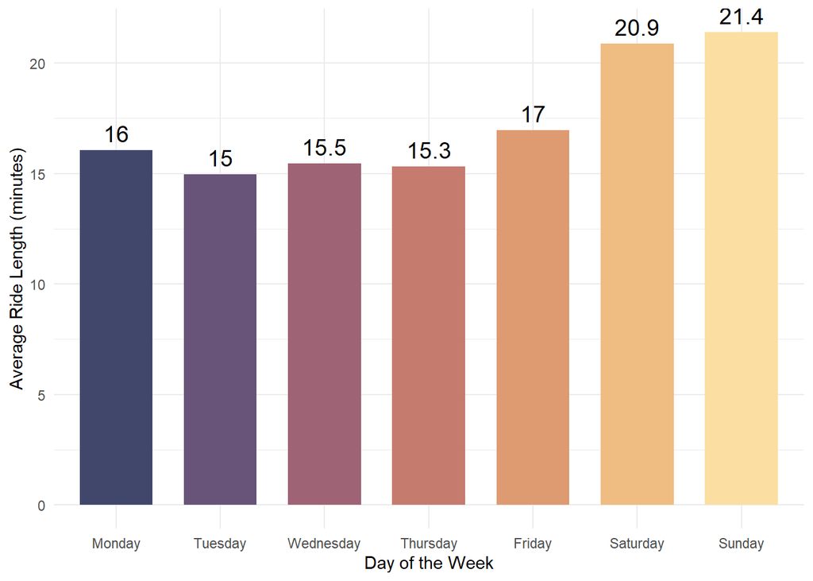

```r
ride_length_by_weekday <- df |>
    mutate(ride_length = as.numeric(difftime(ended_at, started_at, units = "mins")),
           day_of_week = weekdays(as.Date(started_at))) |>
    group_by(day_of_week) |>
    summarise(average_ride_length = mean(ride_length, na.rm = TRUE)) |>
    mutate(day_of_week = fct_relevel(day_of_week, c("Monday", "Tuesday", "Wednesday", "Thursday", "Friday", "Saturday", "Sunday")))

ggplot(ride_length_by_weekday, aes(x = day_of_week, y = average_ride_length, fill = day_of_week)) +
    geom_bar(stat = "identity", width = 0.7) +
    geom_text(aes(label = round(average_ride_length, 1)), vjust = -0.5, size = 5) +
    labs(
        x = "Day of the Week",
        y = "Average Ride Length (minutes)"
    ) +
    theme(legend.position = "none") +
    scale_fill_manual(values = pnw_palette("Sunset", n = 7))
```

This block of code calculates the average ride length for each day of the week and visualizes it in a bar chart. It groups the data by day of the week, computes the average ride length, and then plots this information with bars filled by the day of the week.

## Total Rides By Weekday

Let’s look at the total rides by weekday.

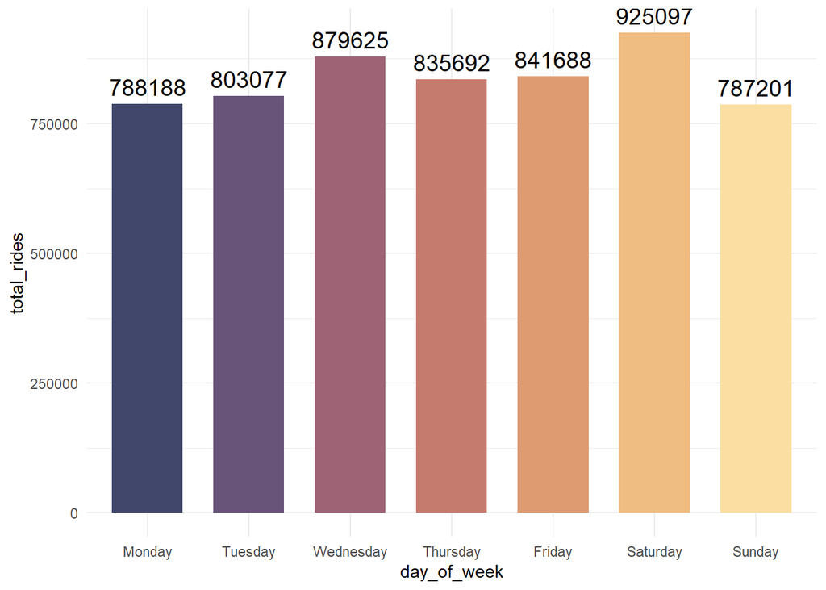

```r
total_rides_by_weekday <- df |>
    mutate(day_of_week = weekdays(as.Date(started_at))) |>
    group_by(day_of_week) |>
    summarise(total_rides = n()) |>
    mutate(day_of_week = fct_relevel(day_of_week, c("Monday", "Tuesday", "Wednesday", "Thursday", "Friday", "Saturday", "Sunday")))

total_rides_by_weekday |>
    ggplot(aes(x = day_of_week, y = total_rides, fill = day_of_week)) +
    geom_bar(stat = "identity", width = 0.7) +
    geom_text(aes(label = total_rides), vjust = -0.5, size = 5) +
  theme(legend.position = "none")+
  scale_fill_manual(values = pnw_palette("Sunset", n = 7))
```

This block of code calculates the total number of rides for each day of the week and visualizes it in a bar chart. It groups the data by day of the week, counts the total rides, and then plots this information with bars filled by the day of the week.

## Total Rides by Hour

Let’s take a look at the total rides by hour and time of day.

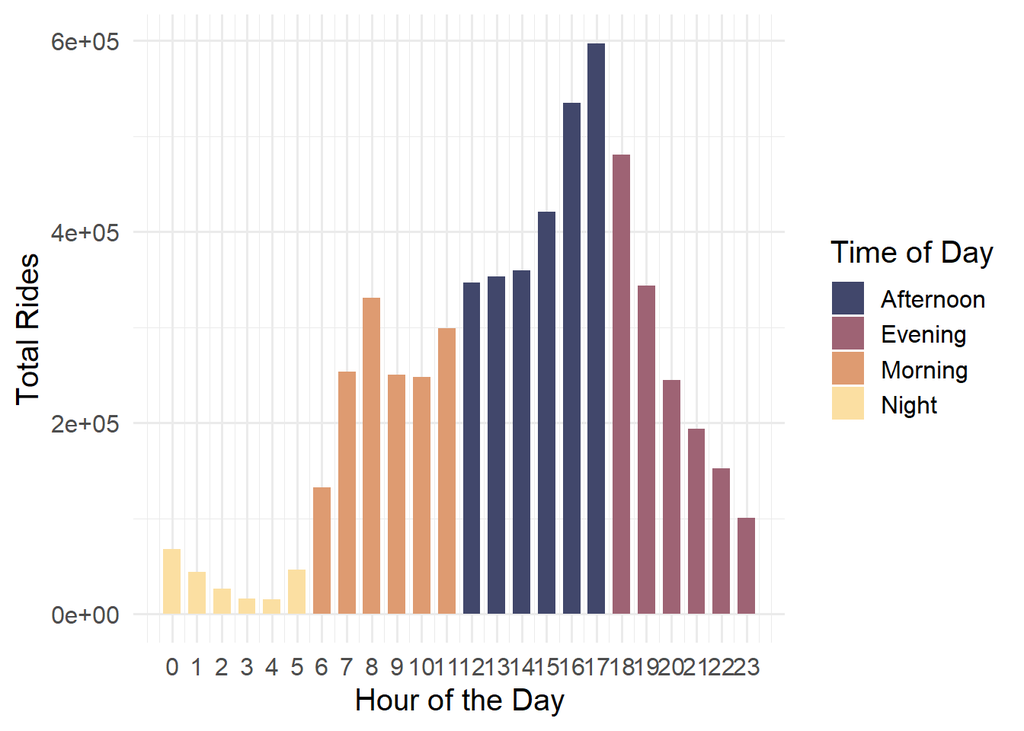

```r
total_rides_by_hour <- df |>
    mutate(hour = hour(started_at)) |>
    group_by(hour, time_of_day) |>
    summarise(total_rides = n(), .groups = 'drop')

total_rides_by_hour |>
    ggplot(aes(x = hour, y = total_rides, fill = time_of_day)) +
    geom_bar(stat = "identity", width = 0.7) +
    scale_x_continuous(breaks = 0:23) +
    labs(
        x = "Hour of the Day",
        y = "Total Rides",
        fill = "Time of Day"
    ) +
    theme_minimal(base_size = 15) + scale_fill_manual(values = pnw_palette("Sunset", n = 4))
```

This block of code calculates the total number of rides for each hour of the day and visualizes it in a bar chart. It groups the data by hour and time of day, counts the total rides, and then plots this information with bars filled by time of day.

## Total Rides by Month

Now let’s look at the total rides by month and season.

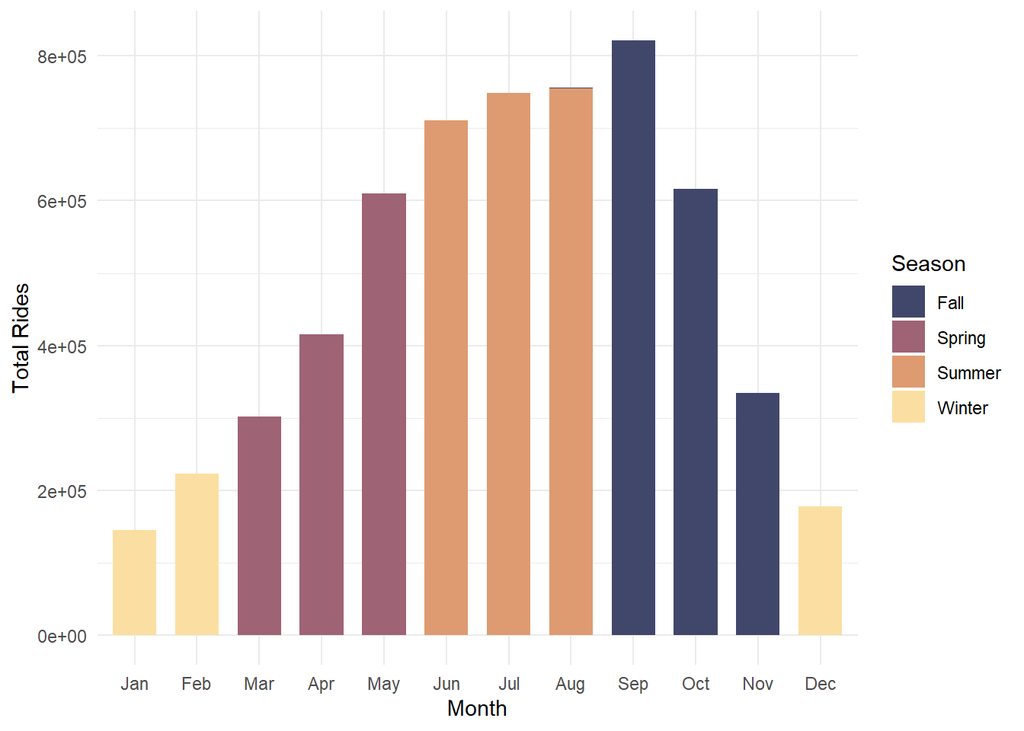

```r
total_rides_by_month <- df |>
    mutate(month = month(started_at, label = TRUE)) |>
    group_by(month, season) |>
    summarise(total_rides = n(), .groups = 'drop')

total_rides_by_month |>
    ggplot(aes(x = month, y = total_rides, fill = season)) +
    geom_bar(stat = "identity", width = 0.7) +
    labs(
        x = "Month",
        y = "Total Rides",
        fill = "Season"
    ) + scale_fill_manual(values = pnw_palette("Sunset", n = 4))
```

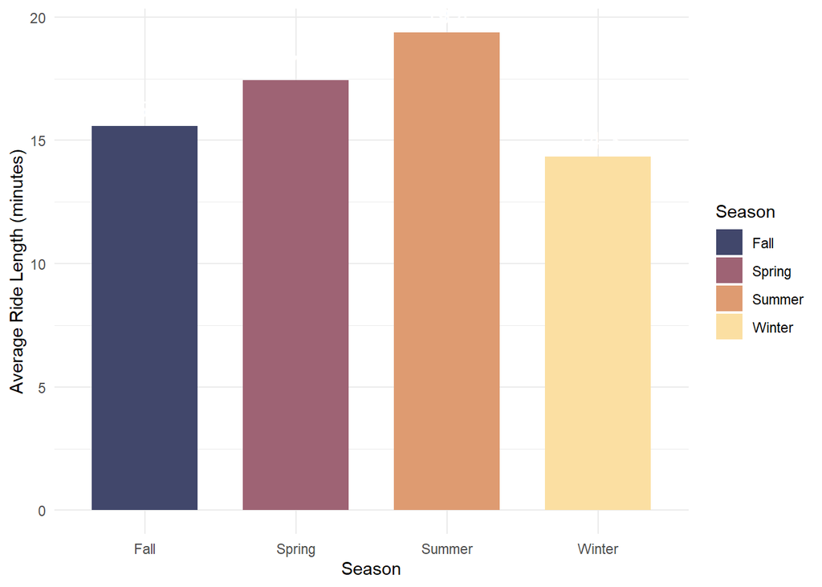

```r
average_ride_length_by_season <- df |>
    mutate(ride_length = as.numeric(difftime(ended_at, started_at, units = "mins"))) |>
    group_by(season) |>
    summarise(average_ride_length = mean(ride_length, na.rm = TRUE), .groups = 'drop')

ggplot(average_ride_length_by_season, aes(x = season, y = average_ride_length, fill = season)) +
    geom_bar(stat = "identity", width = 0.7) +
    geom_text(aes(label = round(average_ride_length, 1)), vjust = -0.5, size = 5, color = "white") +
    labs(
        x = "Season",
        y = "Average Ride Length (minutes)",
        fill = "Season"
    ) +
    scale_fill_manual(values = pnw_palette("Sunset", n = 4))
```

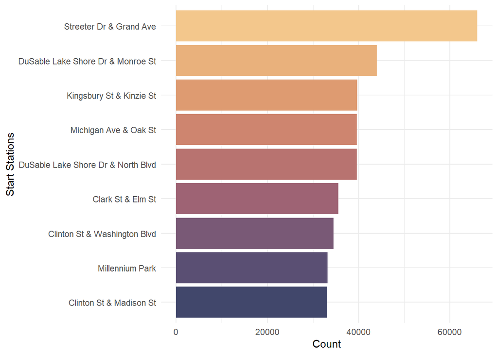

```r
df |>
  mutate(start_station_name = fct_lump(start_station_name, 10)) |>
  count(start_station_id, start_station_name, name = "counts", sort = T) |>
  filter(!is.na(start_station_name),
         !is.na(start_station_id),
         start_station_name != "Other") |>
  mutate(start_station_name = fct_reorder(start_station_name, counts)) |>
  top_n(n=11) |>
  slice(-1) |>
  ggplot(aes(x = start_station_name, y = counts, fill = start_station_name)) +
  geom_bar(stat = "identity") +
  coord_flip() +
  theme(legend.position = "none") +
  labs(y = "Count", x = "Start Stations")+
  scale_fill_manual(values = pnw_palette("Sunset", n = 10))
```

Now let’s look at them on the map.

```r
top_start_location <- df |>
  group_by(start_lat, start_lng) |>
  summarise(counts = n(), .groups = 'drop') |>
  slice_max(order_by = counts, n = 10)

leaflet(top_start_location) |>
  addTiles() |>
  addMarkers(lng = ~start_lng, lat = ~start_lat, popup = ~counts, clusterOptions = markerClusterOptions())
```

[interactive chart not shown]

This code groups the data by starting latitude and longitude, then summarizes the counts of occurrences for each group. It selects the top 10 locations with the highest counts and creates a Leaflet map. The map displays markers at the specified locations with popups showing the counts and enables marker clustering.

**Observations:**

- Most of the Locations are around the downtown and UChicago-Northwestern area.
- The most popular starting and ending stations are very to each other.

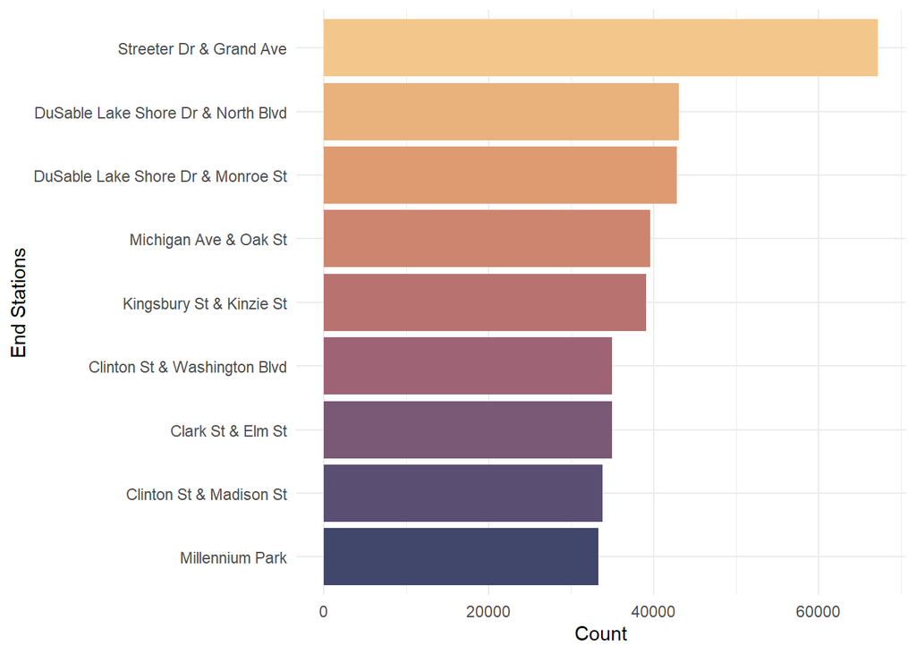

```r
df |>
    mutate(end_station_name = fct_lump(end_station_name, 10)) |>
    count(end_station_id, end_station_name, name = "counts", sort = T) |>
    filter(!is.na(end_station_name),
                 !is.na(end_station_id),
                 end_station_name != "Other") |>
    mutate(end_station_name = fct_reorder(end_station_name, counts)) |>
    top_n(n = 11) |>
    slice(-1) |>
    ggplot(aes(x = end_station_name, y = counts, fill = end_station_name)) +
    geom_bar(stat = "identity") +
    coord_flip() +
  theme(legend.position = "none") +
  labs(y = "Count", x = "End Stations")+
  scale_fill_manual(values = pnw_palette("Sunset", n = 10))
```

Let’s look at them on the map.

```r
top_end_location <- df |>
  group_by(end_lat, end_lng) |>
  summarise(counts = n(), .groups = 'drop') |>
  slice_max(order_by = counts, n = 10)

leaflet(top_end_location) |>
  addTiles() |>
  addMarkers(lng = ~end_lng, lat = ~end_lat, popup = ~counts, clusterOptions = markerClusterOptions())
```

[interactive chart not shown]

The first part of the code uses the `ggplot2` library to create a horizontal bar plot of the top end stations by count. It groups the data by end_station_name, calculates the counts, and then plots these counts with bars filled by the station names, flipping the coordinates for better readability. The second part of the code uses the `leaflet` library to create an interactive map showing the top 10 end locations based on counts. It groups the data by latitude and longitude, calculates the counts, and then adds markers to the map at these locations, with popups displaying the counts and clustering options enabled for better visualization.

**Observations:**

- Most of the Locations are around the downtown and UChicago-Northwestern area.
- The most popular starting and ending stations are very to each other.